# Spring Into Bioinformatics

Visualising Data In R

Steve Pederson

02/10/2019

## Introduction

Now that we know how to import data into R, we’ll start to perform an actual analysis on our dataset. It’s probably quite important to know what we’re working with here.

### Data Description

What we have provided is the results of a gene expression analysis in mice, where we have compared the expression patterns in brain with skeletal muscle. The value we have in our file are the Ensembl gene identifiers (`GeneID`), the difference in gene expression between the two cell types (`logFC`) the average expression of each gene (`logCPM`), the $p$-value for the statistical test comparing expression levels and the expected false discovery rate (`FDR`) if we used that raw $p$-value as our cutoff threshold for significance. In order to keep this dataset manageable over these 3 days, we have restricted our genes to Chromosome 1 only.

### Setting up our R Markdown Document

In the previous section we just copied and pasted our code from the GUI into our R Markdown document, but let’s take a moment now to get this organised a bit better. Make sure you’re happy with your title (although we can clearly change this at any time).

There are two things commonly done at the start of the actual document (*i.e.* after the header): 1) We can set the behaviour of all chunks, and 2) We load all packages at the start for convenience.

#### Setting default options for all chunks

Directly under your YAML header, create a new chunk. You can do this by either typing `` ```{r} `` then closing it with `` ``` ``, or you can insert a new chunk by using the shortcut `Ctrl` + `Alt` + `I`. This should be consistent across all your VMs, but if you’re on MacOS and it doesn’t work, call a tutor over.

Name this chunk `chunkOpts` by typing it after the initial `r` (leaving a space), add a comma after the name, then add the argument `include = FALSE` to the chunk header. Once this is done, enter the following **inside** the chunk:

```
knitr::opts_chunk$set(echo = TRUE)
```

This is not terribly mysterious, but what we have done is:

- Named our chunk
- Hidden the code and any results from the final output (`include = FALSE`)
- Used the command `opts_chunk$set()` from the `knitr` package to ensure that all code is visible in any following chunks (`echo = TRUE`). If we’d set this to FALSE, all R code would be hidden, but any results would be visible.

As you learn more and more, you’ll probably like to set quite a few default behaviour here, but this will do for now.

#### Loading all packages

After the `chunkOpts` chunk:

1. Create a new chunk
2. Name it `loadPackages`
3. Move the code `library(readr)` to this chunk.

```r
library(readr)
```

It’s not essential, but loading all packages at the start is good and common practice, as it does make life easier for your collaborators and for your future self.

#### Describing your data

Hopefully your chunk where you import our list of genes is still sitting there ready to go. Let’s name this chunk `importData` and make sure that only the line which performs the import is left there.

```r
DGE_Results <- read_tsv("data/DGE_Results.tsv")
```

The next most important thing to do now would be to describe our data. Here we have results for 1257 genes from Chromosome 1, so a sensible paragraph might be:

> This set of results contains a comparison of gene expression between skeletal muscle brain tissue. Only the 1257 genes from Chromosome 1 were analysed. Data was imported as a `tibble` with the columns *GeneID*, *logFC*, *logCPM*, *PValue* and *FDR*.

After your chunk which performs the import, write your own paragraph describing our data, making sure you include the number of genes and the column names.

#### Executing R commands in a text paragraph

A super helpful feature of R Markdown is the ability to execute simple R commands within our plain text. We can do this by having an inline section of code, starting with a single backtick and the letter r (`` `r ``), followed by our code, then closed by another single backtick (`` ` ``). Where you’ve written the number 1257, replace this with `` `r nrow(DGE_Results)` ``, and recompile your document.

Here, we’ve used the function `nrow()` to find the number of rows in our object `DGE_Results`, knowing that we have one row per gene. Adding this kind of thing to your data description can be an excellent ‘sanity check’ that your data has loaded correctly too.

Another function which is useful for `tibble`, `data.frame` and `matrix`-type objects is `colnames()`. If you entered `colnames(DGE_Results)` in your Console, this will return your column names. There is another function (`pander()`) which lives inside the package `pander` that we can use to make these look pretty in an R Markdown document.

In your `loadPackages` chunk, add the command `library(pander)` and execute the chunk (hit the green arrow or try using `Ctrl`+`C`). Now where you have your manually typed column names in your paragraph, add the in-line code `` `r pander(colnames(DGE_Results))` ``. This will automatically format them as italic and place the ampersand (`&`) before the last one when you compile your document.

## Visualising Data

Now that we’ve loaded our data and described it, we should actually see what it looks like. A very common thing to check might be the distribution of $p$-values. In statistics, when $H_0$ is true (*i.e.* nothing is happening), these will be drawn from a uniform distribution ranging between 0 and 1. If $H_0$ is not true (*i.e.* something **is** happening), they will be biased towards zero in a manner that somewhat resembles an exponential distribution. In our data, we expect to see a combination of these noting that some genes will not be differentially expressed between cell types ($H_0$ is true), whilst others will be differentially expressed ($H_0$ is false). We can use the base plotting function `hist()` to inspect our $p$-values.

```r
hist(DGE_Results$PValue, breaks = 50)
```

Add the above chunk to your R Markdown document. Notice that we have grabbed the `PValue` column from our `tibble` by using the `$` symbol after the object name. In the Console, type the object name followed by the `$` symbol and R Studio will give you the set of column names to choose from. This is a helpful feature of R Studio that will help you minimise typos. We strongly encourage you to work this way!

You may also notice that each of these columns is very much like our initial object `x` and is in fact a vector. We can use all of our mathematical operations on these columns (except for `GeneID`). Try a few if you’d like.

Returning to our plot, we might like to add a figure caption to this, and some text explaining what we’ve done. Write some text after the chunk saying something along the lines of:

> After loading our data we inspected the distribution of $p$-values and noticed a large number of values near zero, indicating the likelihood that we will see many differentially expressed genes.

In the chunk header, add the argument `fig.cap = "Distribution of $p$-values across all genes"`, then recompile the document.

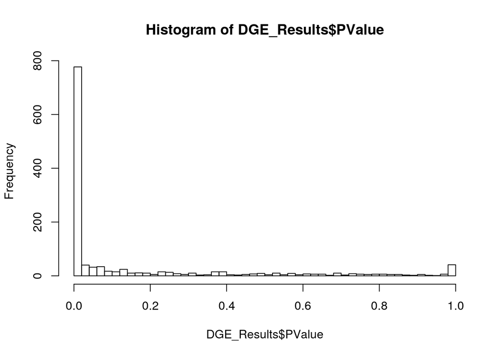

Distribution of $p$-values across all genes

Another plot we might like to make is to compare our average expression (logCPM) to our differential expression (logFC). There is another plotting function called `plot()` where we can just plot to vectors of values against each other. This is sometimes known as an MD plot (*i.e.* a Mean-Difference plot) Now add the following chunk:

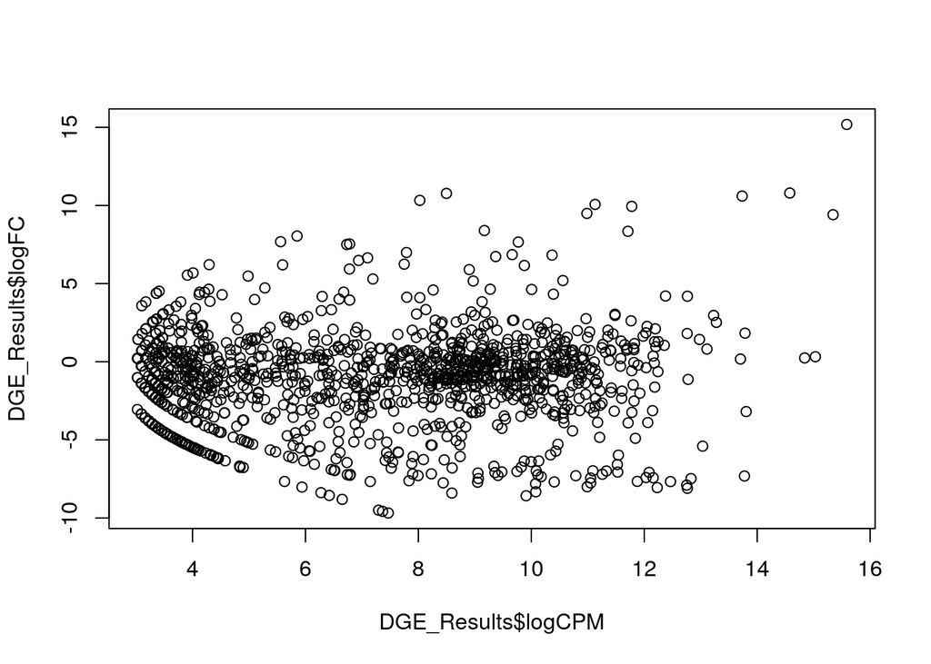

```r
plot(x = DGE_Results$logCPM, y = DGE_Results$logFC)
```

Compile the document and have a look.

### Using ggplot2

These two plots both use plotting functions from the package `graphics` which is loaded by default in every R session, and is very old. In our opinion (and those of most bioinformaticians) these are fairly crude and ugly plots. A far improved plotting package called `ggplot2` was introduced about 10 years ago by Hadley Wickham, and made him a bit of a celebrity amongst R programmers. This package was an implementation of the *Grammar of Graphics* and uses a completely different approach to R’s basic graphics. Let’s start exploring.

First, let’s add the package `ggplot2` to our `loadPackages` chunk and re-execute this to make sure the `ggplot2` is loaded.

```r
library(ggplot2)
```

(NB: The package is `ggplot2`. There was an initial version that was never released by Hadley, however you may hear both `ggplot` and `ggplot2` used in conversation. Formally, `ggplot2` is the name of the package and this is what must be loaded. The primary function we use inside the package is called `ggplot()` so this is the source of the dual language.)

Now we have the package loaded, we can figure out how it all works. The first thing we need to do is initialise the plotting area, and then we’ll decide what plotting geometry we’d like to use. This is done in a layered approach, which may seem strange at first, but is actually very powerful.

In our first call to `ggplot()`, we first pass the data object specifying which values we wish to show as ‘plotting aesthetics’. To make a nicer version of our MD plot, we’d put `logCPM` on the x-axis and `logFC` on the y-axis, so these are our plotting aesthetics. According to `ggplot()` syntax, we need to wrap these inside the function `aes()`.

```r
ggplot(DGE_Results, aes(x = logCPM, y = logFC))
```

This will initialise the plotting area and you’ll see the axis labels looking a little nicer than before, but there will be no points shown. *This is because we haven’t defined which geometry we’re going to use*. The most obvious one to use would be points, so to include this, we add a plotting layer using the `+` symbol, and call the function `geom_point()`.

```r
ggplot(DGE_Results, aes(x = logCPM, y = logFC)) +
    geom_point()
```

Now we have a slightly improved version of our previous plot, but we still have a pesky grey background, which is Hadley’s default setting. (Apparently, he likes it.) `ggplot2` comes with a set of themes that we can add as additional plotting layers. A very useful one is `theme_bw()`, which controls numerous plot attributes like the panel background, axis line colour, axis labels, tick marks, legends etc. Let’s simply add `theme_bw()` as our next plotting layer, and the plot will almost be good enough to publish!

```r
ggplot(DGE_Results, aes(x = logCPM, y = logFC)) +
    geom_point() +
    theme_bw()
```

Let’s add another couple of layers!

It’s very common to apply a threshold for differential expression where we consider anything with a logFC between $\pm1$ to not be biologically relevant, despite any statistical support. This is based on the fact that `logFC` is reported on the $log_2$ scale so these values correspond to a doubling or halving of the expression levels, which is a common-use threshold. This may or may not be realistic, but it is common. Let’s add horizontal lines indicating this range, using the function `geom_hline()`, which stands for a horizontal line.

```r
ggplot(DGE_Results, aes(x = logCPM, y = logFC)) +
    geom_point() +
    geom_hline(yintercept = c(-1, 1), colour = "blue", linetype = 2) +
    theme_bw()
```

There are three helpful things to notice here, and one of them is vital for working with R. The two easy things to see are how we’ve set the colour of the lines (`colour = "blue"`), and the type of line to be dashed (`linetype = 2`). Notice that we quoted the word “blue”. In general, if a text string is unquoted in R, R expects to find this as an R object such as a function, general object, or column in a supplied `tibble`. As we haven’t defined any object called `blue`, we needed to quote this so R knows that this is an actual character string indicating a value. R has 657 colour values predefined with names and unsurprisingly “blue” is one of them.

#### The function `c()`

The final important concept we just glossed over is how we provided values to the `yintercept` argument. Here we used the function `c()` which stands for *combine* or *concatenate*, and we combined the two values -1 and 1 into a single vector. In this way we could pass two y-intercepts in a single call to `geom_hline()`. Otherwise, we might have had to call this function twice.

This idea of forming vectors using the function `c()` is a fundamental design feature of R and you will see this in almost every R script you ever find. This may be a good thing to discuss with the tutors if you’re curious!

### Tidying the plot a bit more

Now we’ve got a pretty good looking plot, we might like to tidy up our x-axis label. All we need to do is provide the values as a character string to the function `labs()`.

```r
ggplot(DGE_Results, aes(x = logCPM, y = logFC)) +
    geom_point() +
    geom_hline(yintercept = c(-1, 1), colour = "blue", linetype = 2) +
    theme_bw() +
    labs(x = "Average Expression (logCPM)")
```

We can use this to change the labels for any attribute we plot, such as the x and y axes, colours, shapes etc.

### Revisiting Our Histogram

Right at the beginning, we made a histogram of our $p$-values using the base plotting function `hist()`. An alternative methed would be to make this plot using `ggplot2`. By default, the histograms don’t look great in `ggplot2`, but with a bit of tweaking, they can be an improvement on those made using the base function.

To set this up for `ggplot2`, our `x` aesthetic would be the $p$-values themselves, whilst the `y` aesthetic would be the counts in each bin along the x-axis. When using the geometry function `geom_histogram()`, `ggplot2` will generate these summaries internally, as did the function `hist()`. The default number of bins is generated internally by `geom_histogram()` using a function called `stat_bin()`, with the number of bins set to 30. If you don’t set the number of bins, you’ll see a friendly message that looks angry, telling you to pick a better value.

```r
ggplot(DGE_Results, aes(x = PValue)) +
  geom_histogram(fill = "grey", colour = "black") +
  theme_bw()
```

Choose a value for `binwidth` and this message will disappear. We could choose `0.02`, which would break our data into 50 bins. Similarly, setting `binwidth = 0.01` would break our data into 100 bins.

```r
ggplot(DGE_Results, aes(x = PValue)) +
  geom_histogram(fill = "grey", colour = "black", binwidth = 0.02) +
  theme_bw()
```

With `geom_histogram()` we can use this method, or just choose the number of bins. Rewriting the above code using `bins = 50` instead of `binwidth = 0.02` will give identical results. Sometimes, it’s just easier to think about our data a certain way so having both options available can be very handy.

### Creating a Volcano Plot

Now that we’ve made a pretty reasonable plot showing how expression levels change against their average value, we might like to create what is known as a *Volcano Plot*. In this type of plot, we would place the difference in expression (*i.e.* `logFC`) on the x-axis, and a measure of statistical significance on the y-axis. A common measure of significance is the $p$-value and for the purposes of plotting, a useful transformation is $-\log_{10}$. Using this approach, $-\log_{10}(0.01) = 2$ and $-\log_{10}(0.001) = 3$ and so on. This is a way of obtaining an increasing score for significance which looks informative on a plot. Additionally, we know that $p$-values between 0.05 and 1 are not very interesting, so this transformation will squash them together whilst highlighting the differences in significance for low $p$-values (*i.e.* p < 0.05). We can perform this transformation directly in `ggplot()`!

```r
ggplot(DGE_Results, aes(logFC, -log10(PValue))) +
    geom_point() +
    geom_vline(xintercept = c(-1, 1), linetype = 2, colour = "blue") +
    labs(y = "-log10(p)") +
    theme_bw()
```

This is a pretty reasonable looking plot already, but wouldn’t it be great to show a few extra things like: 1) gene names, 2) which genes are considered DE, or 3) which $p$-value corresponds to an FDR (*i.e* False Discovery Rate) of 0.05? For that, we’ll need to have a look at another extremely useful package called `dplyr`.